# Lab3 report

Yi Hung Chen, Jonathan Dorairaj

2023-05-14

## Q1 Gibbs sampler for a normal model

### (a Implement (code!) a Gibbs sampler that simulates from the joint posterior

```r
library(ggplot2)
library(mvtnorm)
precipitation <- readRDS("Precipitation.rds")
log_prec <- log(precipitation)

mu_post <- function(mu_0,tau_0_sqr,sigma_sqr_current,y,n){

  tau_n_sqr = 1 / (1/tau_0_sqr + n/sigma_sqr_current)
  mu_n <- tau_n_sqr * (mu_0/tau_0_sqr + sum(y)/sigma_sqr_current)
  mupost <- rnorm(1, mu_n, sqrt(tau_n_sqr))
  return(mupost)

}

sigma_sqr_post <- function(mu_current, v_0, sigma_sqr_0, y,n, use_myinvchi=TRUE) {

  v_n <- v_0 + n
  elem1 <- v_0*sigma_sqr_0
  elem2 <- sum((y - mu_current)^2)
  elem3 <- n+v_0
  elem_comb <- (elem1+elem2)/elem3
  if (use_myinvchi){
    sigma_sqr_post <- my_inv_chi(v_n,elem_comb)
  }
  else {
    sigma_sqr_post <- rinvchisq(1, v_n, elem_comb) #Requires package extraDistr
  }



  return(sigma_sqr_post)
}

my_inv_chi<- function(df,tau_sqr) {
  X <- rchisq(1,df)
  inv_chi <- (df*tau_sqr)/X
  return(inv_chi)
}

#init
mu_0 <- 0
tau_0_sqr <- 1
sigma_sqr_0 <- 1
v_0 <- 1 #degree of freedom for chi square

gibbs_sampler <- function(nstep, data, mu_0, tau_0_sqr, v_0, sigma_sqr_0) {
  # Init parameters
  mu_current <- 0
  sigma_sqr_current <- 1

  mu_samples <- rep(0,nstep)
  sigma_sqr_samples <- rep(0,nstep)

  for (i in 1:nstep) {

    mu_current <- mu_post(mu_0, tau_0_sqr, sigma_sqr_current, y=data, length(data))
    #print(mu_current)
    sigma_sqr_current <- sigma_sqr_post(mu_current, v_0, sigma_sqr_0, y=data,
                                        length(data),use_myinvchi=TRUE)
    #print(sigma_sqr_current)

    mu_samples[i] <- mu_current
    sigma_sqr_samples[i] <- sigma_sqr_current
  }

  output_df <- data.frame(mu_sample = mu_samples, sigma_sample = sigma_sqr_samples)
  return(output_df)
}

sample_gibbs <- gibbs_sampler(nstep=10000, data=log_prec, mu_0, tau_0_sqr, v_0, sigma_sqr_0)
```

In lecture slide$IF = 1 + 2\sum^{\infty}_{k=1} \rho_k$ where $\rho_k$ is autocorrelation at lag k

```r
my_acf <- acf(sample_gibbs$mu_sample,plot = F) # getting the autocorrelation
if_mu <- 1 + 2 * sum(my_acf$acf[-1])
my_acf <- acf(sample_gibbs$sigma_sample,plot = F)
if_sigma <- 1 + 2 * sum(my_acf$acf[-1])
```

The the Inefficiency Factors (IF) of $\mu$ = 0.9982076 and IF of $\sigma$ = 0.9522093. The value of IF is around 1 indicates that the chain has converged to the stationary distribution.

Below, we present two trace plot that also confirm the samples’ convergence.

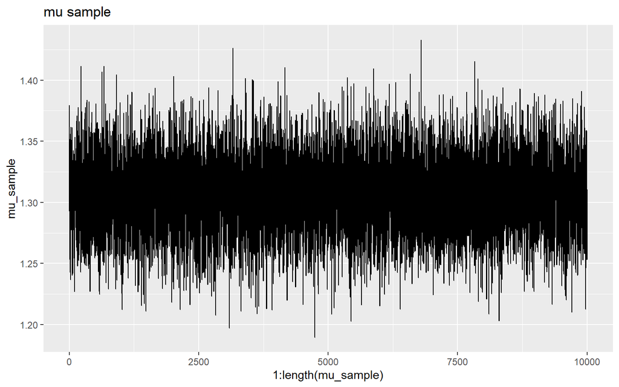

```r
ggplot(data=sample_gibbs, aes(x = 1:length(mu_sample), y = mu_sample)) +
  geom_line()+labs(title = "mu sample")
```

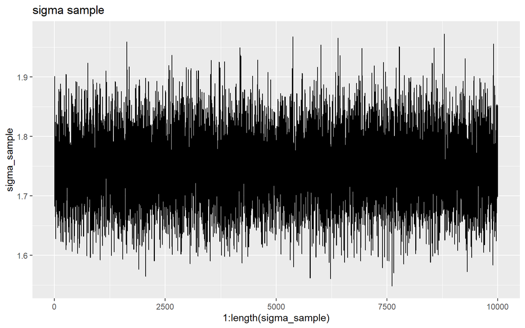

```r
ggplot(data=sample_gibbs, aes(x = 1:length(sigma_sample), y = sigma_sample)) +
  geom_line() +labs(title = "sigma sample")
```

###(b) Plot the following in one figure: 1) a histogram or kernel density estimate of the daily precipitation  
2) The resulting posterior predictive density using the simulated posterior draws from How well does the posterior predictive density agree with this data?

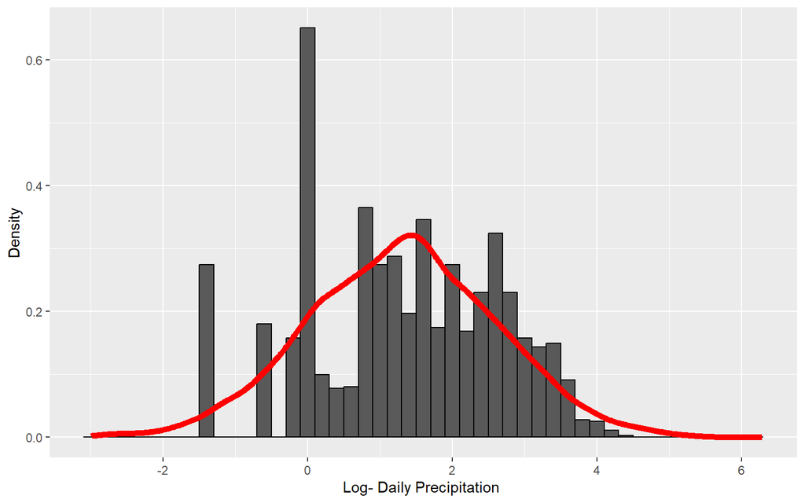

```r
# Using Gibbs sample's mu and sigma to sample posterior prediction
post_pred_samples <- rnorm(n = 10000, mean = sample_gibbs$mu_sample,
                           sd = sqrt(sample_gibbs$sigma_sample))

ggplot(data = data.frame(y = log_prec), aes(x = y)) +
  geom_histogram(aes(y =after_stat(density)), color = "black", binwidth = 0.2) +
  geom_density(data = data.frame(y = post_pred_samples), aes(x = y, y = after_stat(density)),
               color = "red",linewidth = 2) +
  labs(x = "Log- Daily Precipitation ", y = "Density")
```

Above is the plot of the histogram of the daily precipitation, and the resulting posterior predictive density(red line). We can say that the posterior prediction does not totally agree with the existing data, especially towards to left-hand side of the mode.

## Q3 Time series models in Stan

###(a Write a function in R that simulates data from the AR(1)-process

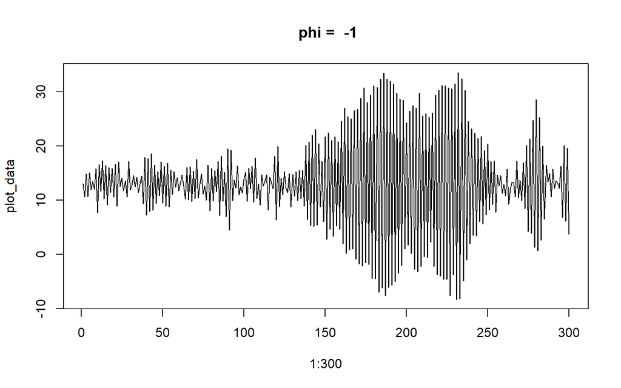

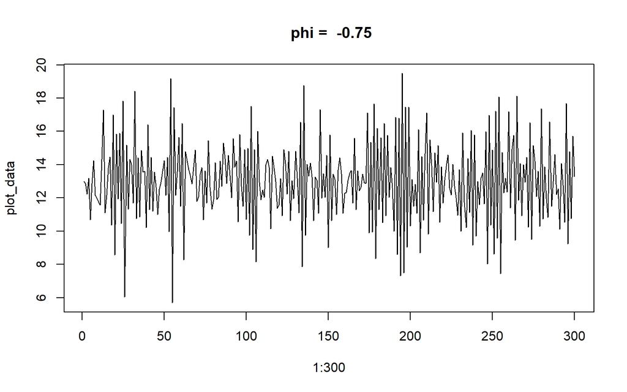

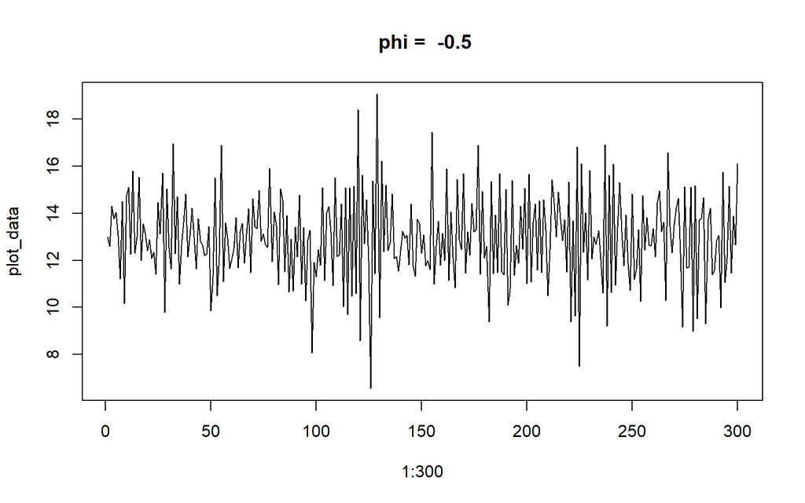

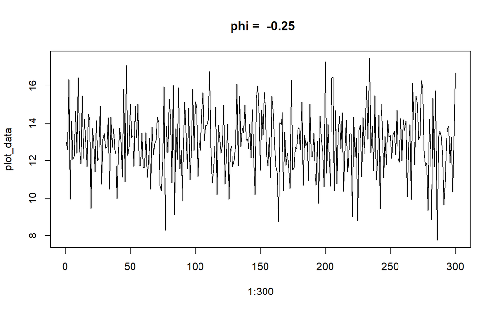

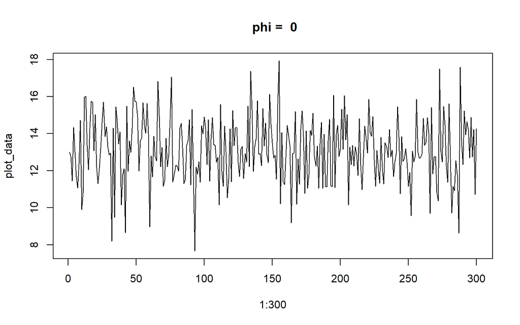

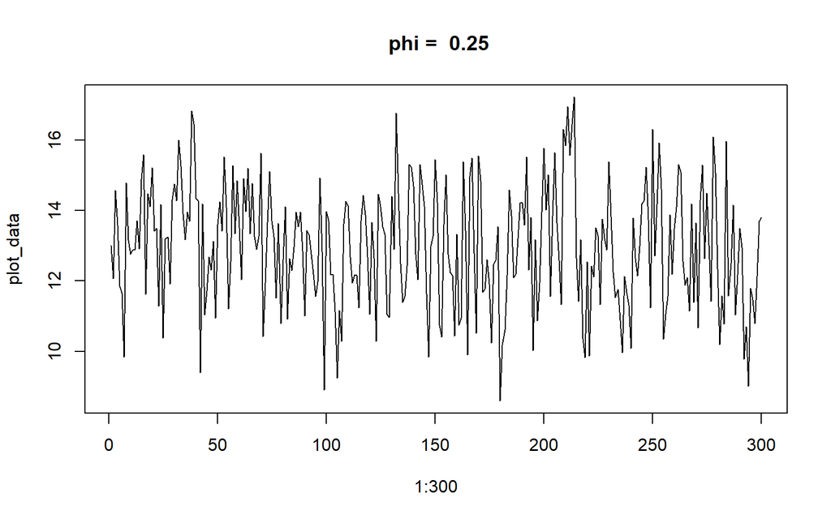

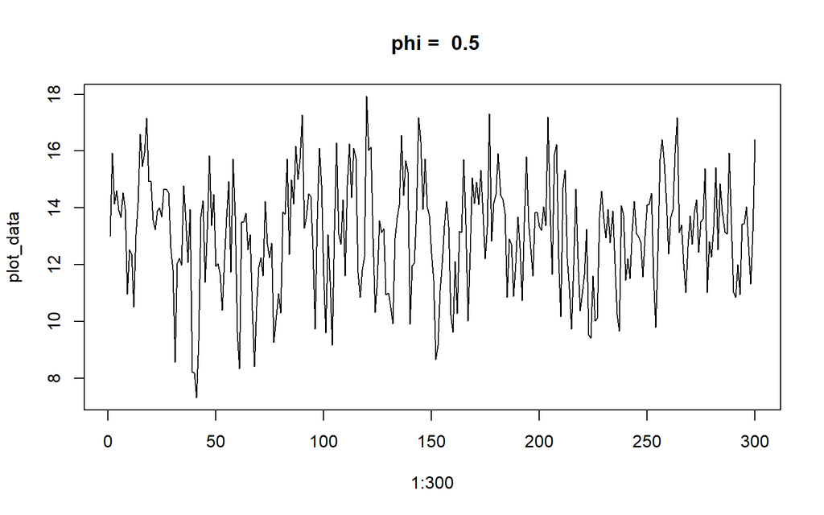

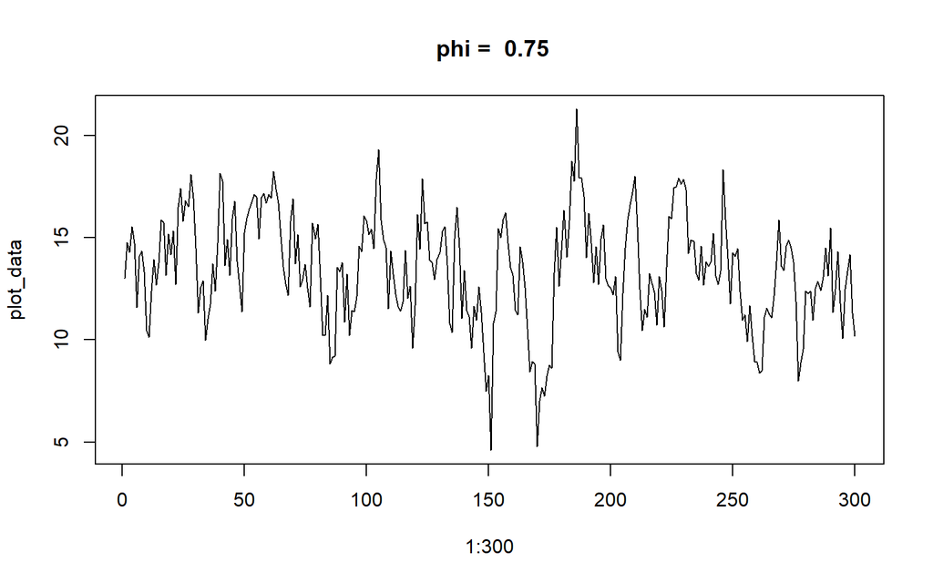

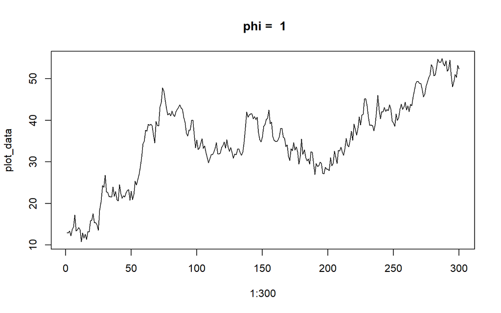

```r
mu <- 13
sigma_sqr <- 3
t <- 300
phi <- seq(from = -1 ,to = 1, by =0.25 )

ar_func <- function(phi,mu,sigma_sqr,t){
  counter <- 0
  result_vector <- rep(0,t)
  result_vector[1] <- mu
  for(i in 2:t){
    epislon <- rnorm(1,0,sqrt(sigma_sqr))
    x_i <- mu+phi*(result_vector[i-1]-mu)+ epislon
    result_vector[i] <- x_i
  }

  return(result_vector)
}


test_phi_func <- function(phi,mu,sigma_sqr,t){

  phi_test_df <- data.frame(matrix(0, nrow = t, ncol = length(phi)))
  colnames(phi_test_df) <- phi

  for (j in 1:length(phi)) {
    phi_test <- ar_func(phi[j], mu, sigma_sqr, t)
    phi_test_df[, j] <- phi_test
  }
  return(phi_test_df)
}
phi_df <- test_phi_func(phi,mu,sigma_sqr,t)


for(k in 1:length(phi)){
  plot_data <- phi_df[,k]
  plot(x=1:300, plot_data, type = "l", main = paste(" phi = ", phi[k]))
  #Sys.sleep(1)
}
```

As we can observed with different $\phi$, as $\phi$ increase, the gap between peaks are getting larger. This indicate that the data tends to have higher autocorrelation, which means each data point is more correlated with preceding data.

### (b

Rstan

```r
library(rstan)
library(StanHeaders)
set.seed(12345)
x <- ar_func(phi=0.2, mu, sigma_sqr, t)
y <- ar_func(phi=0.95, mu, sigma_sqr, t)

stan_code <- "
data {
  int<lower=0> T;         // Number of time points
  vector[T] x;
  vector[T] y;
}
parameters {
  real mu_x;
  real mu_y;
  real phi_x;
  real phi_y;
  real sigma_x;
  real sigma_y;
}
model {
  // After some research, it is common to use a flat prior or a vague prior as
  // non-informative prior
  // Therefore, we pick normal distribution with higher variance as prior.
  mu_x ~ normal(0, 50);
  mu_y ~ normal(0, 50);
  phi_x ~ normal(0, 10);
  phi_y ~ normal(0, 10);

  sigma_x  ~ normal(0, 50);
  sigma_y  ~ normal(0, 50);


  x[2:T] ~ normal(mu_x + phi_x * (x[1:(T - 1)] - mu_x), sigma_x);
  y[2:T] ~ normal(mu_y + phi_y * (y[1:(T - 1)] - mu_y), sigma_y);
}
"



data_list <- list(
  T = t,
  x = x,
  y = y
)

# Set the MCMC settings
niter <- 2500
warmup <- 500

# Compile the Stan model
model <- stan_model(model_code = stan_code)

# Fit the Stan model to the data
# Set the conture to avoid too many divergent after warmup
control <- list(adapt_delta = 0.90, stepsize = 0.0001)
fit<- sampling(model, data = data_list, warmup = warmup, iter = niter, chains = 5,control=control,refresh = 0)
#refresh = 0 to mute the printout
summary(fit)$summary
```

```
##                 mean      se_mean          sd          2.5%          25%
## mu_x      13.1730935 0.0014221810  0.12799423   12.91958674   13.0877503
## mu_y      14.5835783 0.6316940067 10.59174307  -15.73755194   12.7590975
## phi_x      0.1879295 0.0007119376  0.05716125    0.07528928    0.1494481
## phi_y      0.9722140 0.0004649779  0.01854910    0.93533707    0.9591935
## sigma_x    1.7883626 0.0008844564  0.07374353    1.64838184    1.7381002
## sigma_y    1.7238175 0.0009294386  0.07098908    1.59007666    1.6748084
## lp__    -634.2569913 0.0406928054  1.84243428 -638.52339263 -635.3553187
##                  50%          75%        97.5%     n_eff      Rhat
## mu_x      13.1729080   13.2598556   13.4185023 8099.7393 1.0005417
## mu_y      15.4944969   18.1682051   35.6705288  281.1392 1.0173262
## phi_x      0.1879285    0.2266257    0.2974586 6446.4363 1.0004338
## phi_y      0.9724578    0.9870265    1.0023830 1591.4067 1.0032073
## sigma_x    1.7859224    1.8368152    1.9412147 6951.7626 0.9998293
## sigma_y    1.7222291    1.7705077    1.8690934 5833.6674 1.0003013
## lp__    -633.9629019 -632.8609105 -631.5264207 2049.9759 1.0008693
```

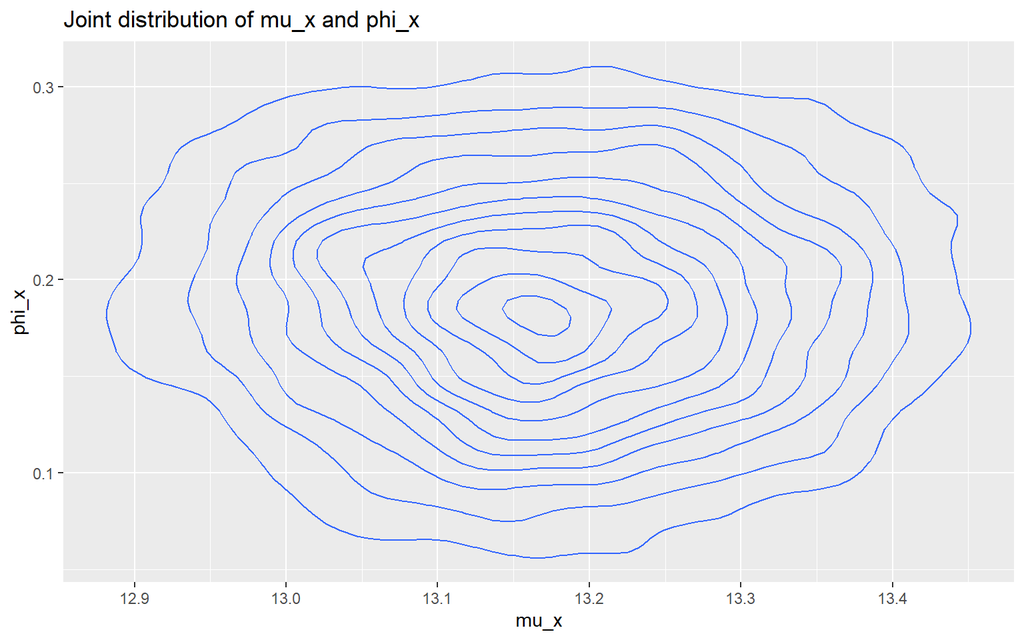

```r
posterior_x <- extract(fit, pars = c("mu_x", "phi_x"))
posterior_df_x <- data.frame(posterior_x)
ggplot(data = posterior_df_x, aes(x = mu_x, y = phi_x)) +
  stat_density_2d() +
  xlab("mu_x") +
  ylab("phi_x") +
  ggtitle("Joint distribution of mu_x and phi_x")
```

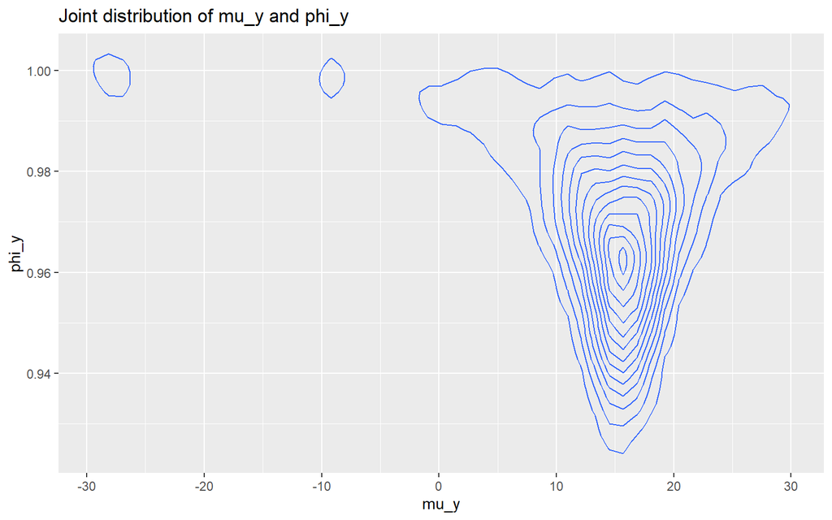

```r
posterior_y <- extract(fit, pars = c("mu_y", "phi_y"))
posterior_df_y <- data.frame(posterior_y)
ggplot(data = posterior_df_y, aes(x = mu_y, y = phi_y)) +
  stat_density_2d()+
  xlab("mu_y") +
  ylab("phi_y") +
  ggtitle("Joint distribution of mu_y and phi_y")
```